# Homicide Rate, Suicide Rate and GDP over 50 Years

Introduction to R for Data Science and Computational Social Sciences

Ursulina Kölbener, Cand. Lucerne Master in Computational Social Sciences

2022-11-18

## Setup

```r
# install.packages("tidyverse")
library(tidyverse)
# install.packages("stargazer")
library(stargazer)
# install.packages("viridis")
library(viridis)
```

## 1. Dataset

The dataset contains intentional homicide rates, suicide rate and gross domestic product (GDP) from 1970 to 2020 by country. The data source is [the world bank](https://data.worldbank.org/). I found the dataset on kaggle.

```r
# import dataset
shg_original <- rio::import("data/suicide_homicide_gdp.csv")
```

### Describing the Dataset

There are 13’566 observations with 10 variables. The country name is represeneted in three different ways. Once completely written out («country»), once abbreviated according to the iso standard with 3 characters («iso3c») and once abbreviated according to the iso standard with 2 characters («iso2c»).

```r
# number of observations
nrow(shg_original)
```

```
## [1] 13566
```

```r
# numer of variables
ncol(shg_original)
```

```
## [1] 10
```

### Describing Variables, Type and Measurement Level

The dataset shows observations from 1970 to 2020 («year») as a integer data type. Further there are four numerical values: «Intentional homicides (per 100,000 people)», «Suicide mortality rate (per 100,000 population)», Gross Domestic Product «GDP (current USD)» and «GDP per capita, PPP (current international $)». Intentional homicides and suicide mortality rate are discrete values. Gross domestic product (GDP) is a continuous variable, a monetary measure of the market value of all the final goods and services produced and sold (not resold) in a specific time period by countries. Gross domestic product (GDP) per capita is a financial metric that breaks down a country’s economic output per person and is calculated by dividing the GDP of a nation by its population. The values of the GDP per capita reach from 285.4 to 153563.9.

Finally, the region («adminregion») and income level («incomeLevel») are specified as characters. Region and income level are categorical variables. Income level is somewhat ordinal with the following values: Aggregates, High income, Low income, Lower middle income and Upper middle income. A few variables are not classified, others are aggregates. I will remove them later.

```r
# check data type of every variable
str(shg_original)
```

```
## 'data.frame':    13566 obs. of  10 variables:
##  $ country                                        : chr  "Afghanistan" "Afghanistan" "Afghanistan" "Afghanistan" ...
##  $ iso3c                                          : chr  "AFG" "AFG" "AFG" "AFG" ...
##  $ iso2c                                          : chr  "AF" "AF" "AF" "AF" ...
##  $ year                                           : int  1970 1971 1972 1973 1974 1975 1976 1977 1978 1979 ...
##  $ Intentional homicides (per 100,000 people)     : num  NA NA NA NA NA NA NA NA NA NA ...
##  $ Suicide mortality rate (per 100,000 population): num  NA NA NA NA NA NA NA NA NA NA ...
##  $ GDP (current US$)                              : num  1.75e+09 1.83e+09 1.60e+09 1.73e+09 2.16e+09 ...
##  $ GDP per capita, PPP (current international $)  : num  NA NA NA NA NA NA NA NA NA NA ...
##  $ adminregion                                    : chr  "South Asia" "South Asia" "South Asia" "South Asia" ...
##  $ incomeLevel                                    : chr  "Low income" "Low income" "Low income" "Low income" ...
```

```r
# summary statistics
summary(shg_original)
```

```
##    country             iso3c              iso2c                year
##  Length:13566       Length:13566       Length:13566       Min.   :1970
##  Class :character   Class :character   Class :character   1st Qu.:1982
##  Mode  :character   Mode  :character   Mode  :character   Median :1995
##                                                           Mean   :1995
##                                                           3rd Qu.:2008
##                                                           Max.   :2020
##
##  Intentional homicides (per 100,000 people)
##  Min.   :  0.000
##  1st Qu.:  1.356
##  Median :  3.409
##  Mean   :  8.044
##  3rd Qu.:  9.247
##  Max.   :141.723
##  NA's   :9726
##  Suicide mortality rate (per 100,000 population) GDP (current US$)
##  Min.   : 0.00                                   Min.   :8.824e+06
##  1st Qu.: 5.40                                   1st Qu.:2.936e+09
##  Median : 8.50                                   Median :2.136e+10
##  Mean   :10.54                                   Mean   :1.256e+12
##  3rd Qu.:13.20                                   3rd Qu.:2.584e+11
##  Max.   :92.60                                   Max.   :8.757e+13
##  NA's   :8946                                    NA's   :2170
##  GDP per capita, PPP (current international $) adminregion
##  Min.   :   285.4                              Length:13566
##  1st Qu.:  2875.3                              Class :character
##  Median :  7525.3                              Mode  :character
##  Mean   : 14326.4
##  3rd Qu.: 18717.5
##  Max.   :153563.9
##  NA's   :6328
##  incomeLevel
##  Length:13566
##  Class :character
##  Mode  :character
##
##
##
##
```

### Research Questions

Do intentional homicides correlate with gross domestic product (GDP) in genereal? What are the differences in regions over the years?

Does a high homicide rate favor a high suicide mortality rate?

## 2. Summary Statistics

### Removing Incomplete Observations

Transforming the data for easier handling. Also, the dataset contains lot’s of variables with NA. Removing those NA’s leaves 2352 observations.

```r
# creating a new dataset from the original data
shg <- shg_original

# renaming the variables to easier names
shg <- rename(shg, IntHomicides = `Intentional homicides (per 100,000 people)`,
              SuicideMort = `Suicide mortality rate (per 100,000 population)`,
              GDP = `GDP (current US$)`,
              GDPcap = `GDP per capita, PPP (current international $)`,
              region = `adminregion`)

# removing all observations with NA's
shg <- shg %>%
  filter(incomeLevel != "Aggregates" & incomeLevel != "Not classified" ) %>%
  filter(!is.na(IntHomicides)) %>%
  filter(!is.na(SuicideMort))
```

### Frequency Table

For the **income level**: There are 897 observations with high income, 757 with upper middle income, 560 with lower middle income and 132 observations with low income.

```r
# calculate frequency of income level
table(shg$incomeLevel)
```

```
##
##                             High income          Low income Lower middle income
##                   6                 897                 132                 560
## Upper middle income
##                 757
```

### Summary

**GDP per capita**: The minimum value is 532.5 and the maximum 141634.7. The mean has a value of 19491.1, the medain is lower at 12506.5.

```r
# summary of GDP per capita
summary(shg$GDPcap)
```

```
##     Min.  1st Qu.   Median     Mean  3rd Qu.     Max.     NA's
##    532.5   5825.7  12506.5  19491.1  28827.8 141634.7       29
```

## 3. Data Transformation

### Removing More Incomplete Observations

The column «iso3c» is not necessary. Further I discovered a few *total* rows in between the rest of the data, which should be removed.

```r
# create a new subset
shg_trnsf <- shg %>%
  select(-iso3c) %>% # remove column iso3c
  filter(iso2c != "") # remove rows (total per region)
```

### Merge With Another Dataset

As the regions in the dataset are incomplete and do not match the ISO standard, I imported a proper list («region») with countries and their regions, then merging the two tables together. I used `merge`as I could not figure out how it works with `inner_join`.

```r
# import a second dataset
region <- rio::import("data/region.csv")

# rename columns for easier merging
region <- rename(region, iso2c = `alpha-2`,
                 regionISO = `region`)

# combining with another dataset
shg_exp <- merge(x = shg_trnsf, y = region, by = "iso2c")
```

## 4. Data Vizualization

### Subset to Vizualize Global Trends

Firstly, I’d like to show the general global trend from GDP per capita, Intentional Homicides and Suicide Mortality by region.

```r
# calculate the sum of two continuous variables and the average of one
shg_trend <- shg_exp %>%
  group_by(regionISO, year) %>%
  summarise(sum_IntHomicides = sum(IntHomicides, na.rm = TRUE),
            sum_SuicideMort = sum(SuicideMort, na.rm = TRUE),
            avg_GDPcap = mean(GDPcap, na.rm = TRUE))
# show summarized data
shg_trend
```

```
## # A tibble: 95 × 5
## # Groups:   regionISO [5]
##    regionISO  year sum_IntHomicides sum_SuicideMort avg_GDPcap
##    <chr>     <int>            <dbl>           <dbl>      <dbl>
##  1 Africa     2000             81.0            107.      4352.
##  2 Africa     2001            112.             151.      3751.
##  3 Africa     2002            108.             163       3602.
##  4 Africa     2003            128.             208.      4389.
##  5 Africa     2004            136.             226.      5062.
##  6 Africa     2005            120.             215       5052.
##  7 Africa     2006            134.             234.      5633.
##  8 Africa     2007            171.             279.      5766.
##  9 Africa     2008            194.             319.      5528.
## 10 Africa     2009            183.             312.      5802.
## # … with 85 more rows
```

### Line Plots Showing Global Trends

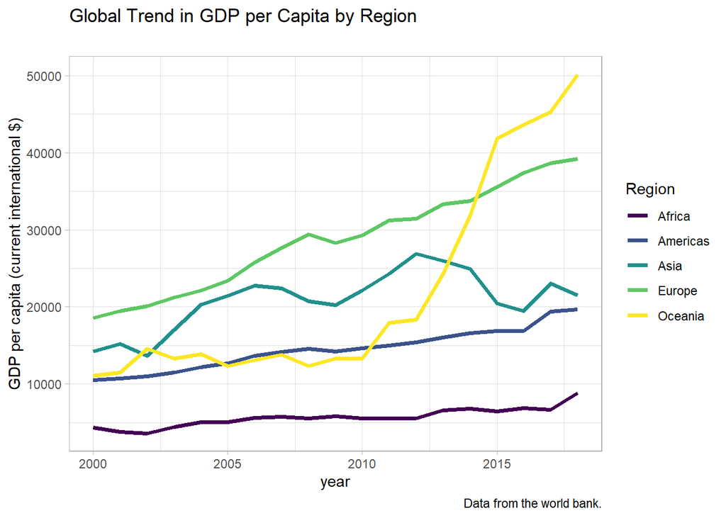

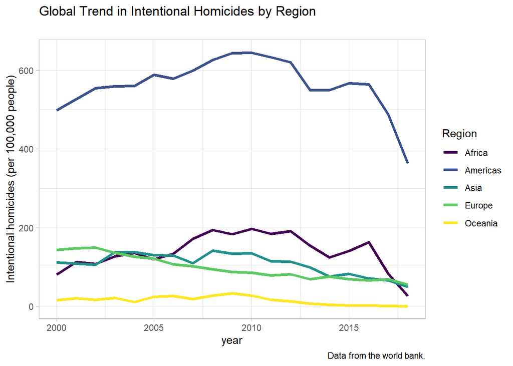

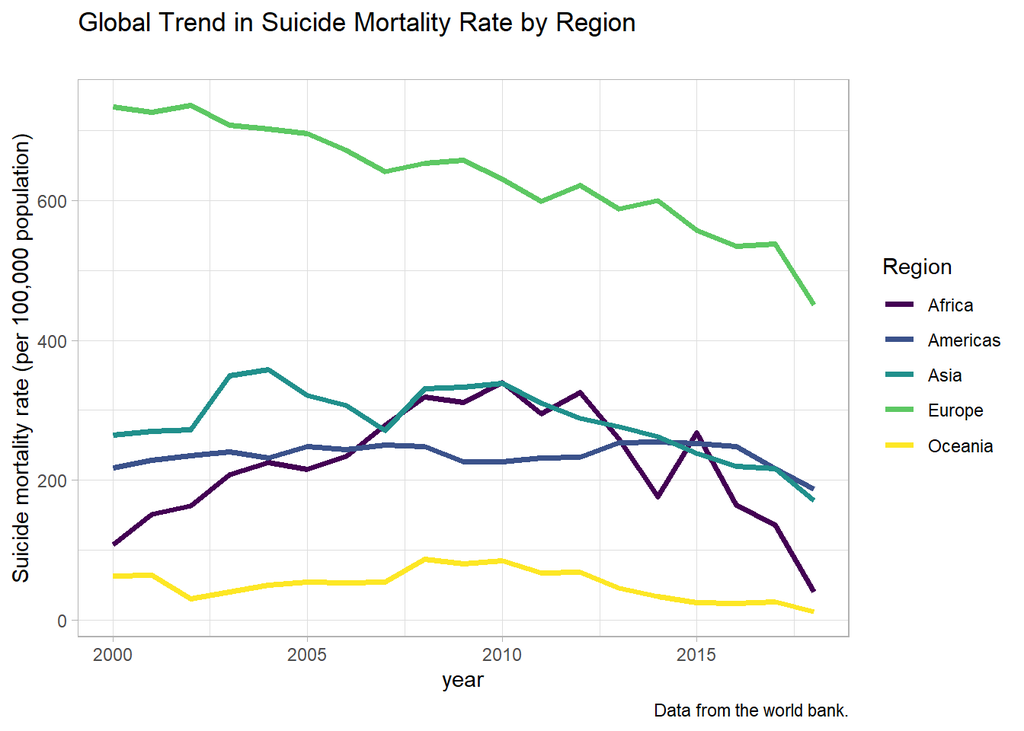

### Global Trend Comparing Suicide Mortality Rate and Intentional Homicides

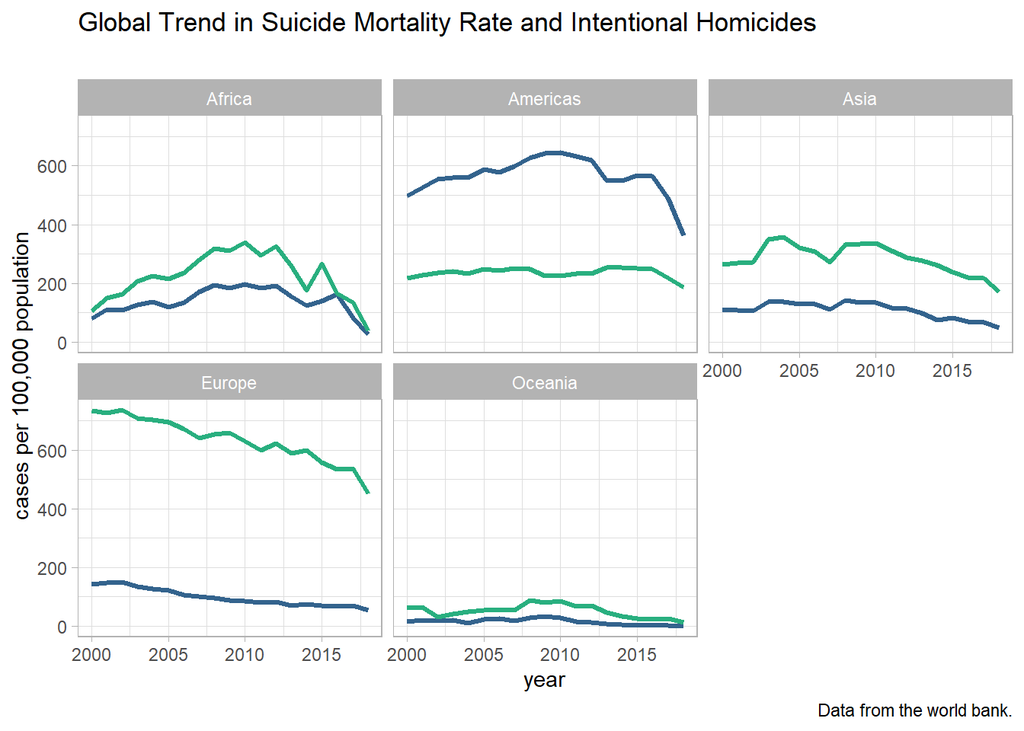

### Relationship Between GDP per Capita and Intentional Homicides

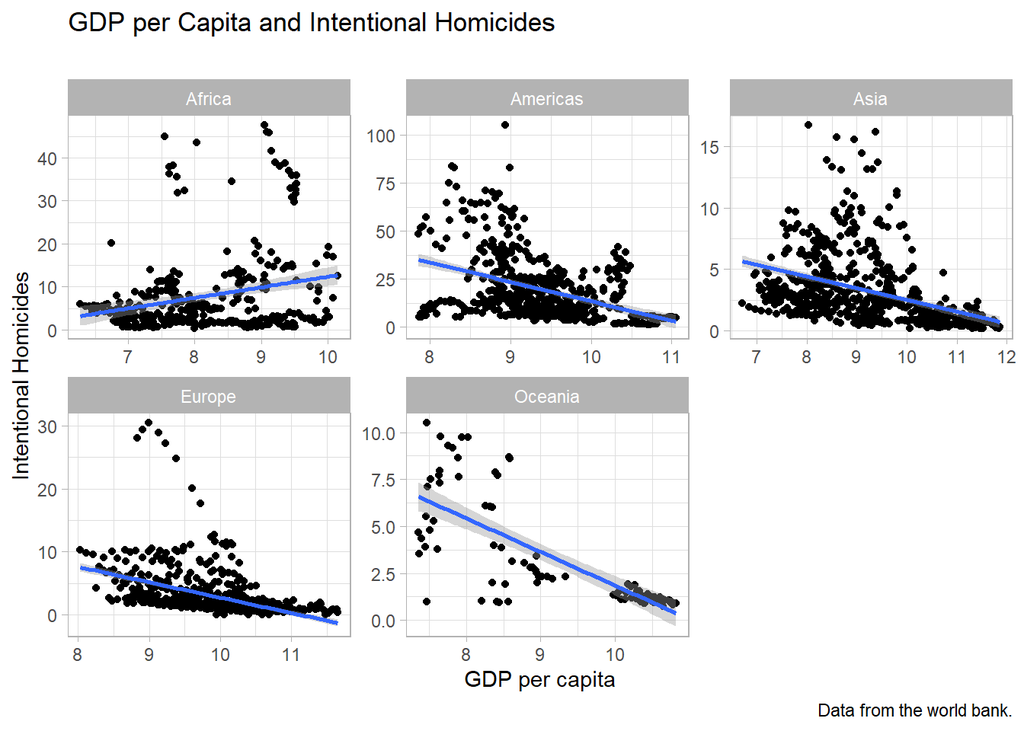

### Suicide Mortality Rate by Sub-Regions

This makes more sense to only show one year and compare the sub-regions. So creating a subset, group, summarise and arrange descending.

```r
# create a subset
shg_2018 <- shg_exp %>%
  filter(year == 2018) %>% # only observations from 2018
  group_by(`sub-region`, regionISO) %>% # grouped by sub-region and region (for colour fill)
  summarise(sumSuicideMort = sum(SuicideMort)) %>% # calculate sum
  arrange(desc(sumSuicideMort)) # order descending
```

Then creating a plot an turning the text on the x-axis.

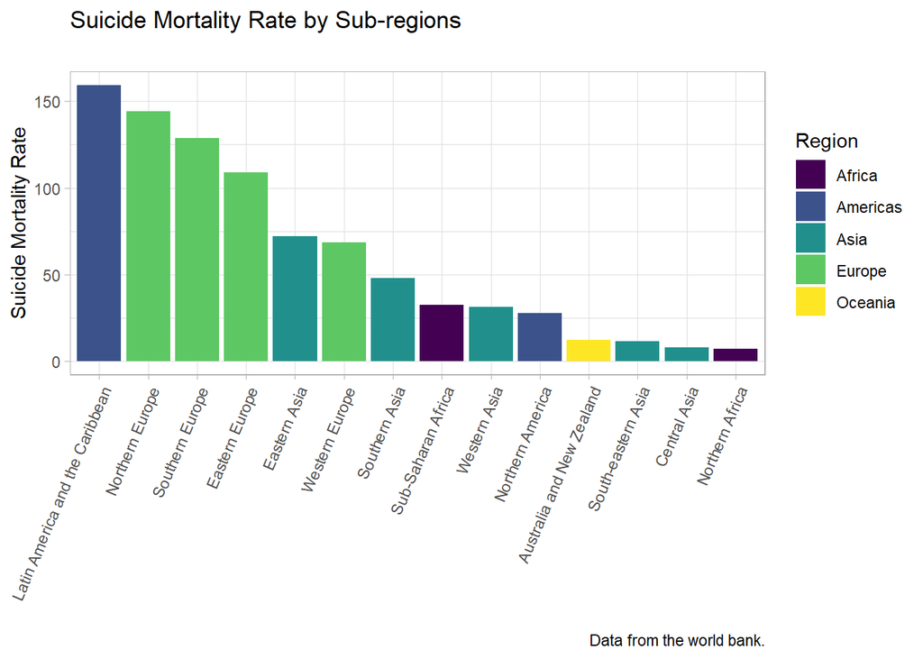

### Countries With the Highest Mortality Rate

```r
# create a subset
shg_2018_top20 <- shg_exp %>%
  filter(year == 2018) %>% # only observations from 2018
  arrange(desc(SuicideMort)) %>% # order descending
  top_n(20, SuicideMort) # keep only top 20
```

Plotting the data and reorder the x-axis. The order would be alphabetical, if the arguments are not changed.

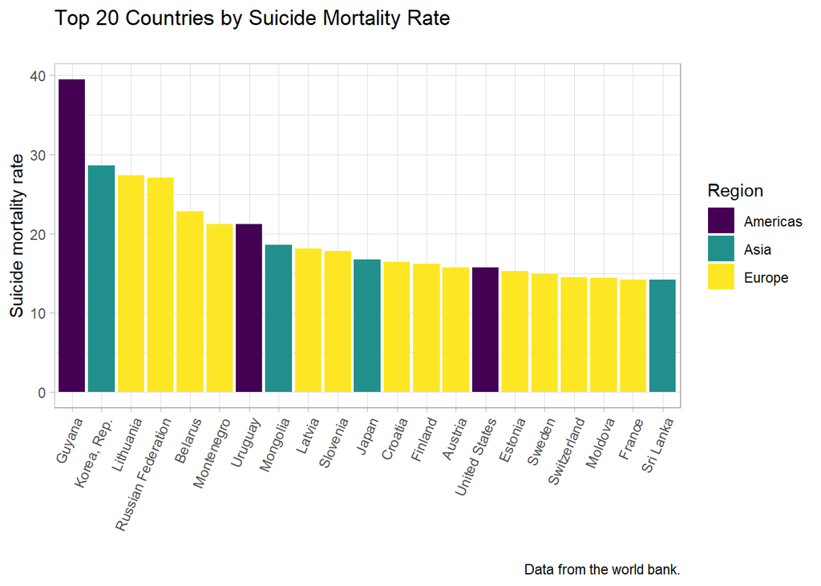

### Boxplot Income Level

I am using income level as the horizontal variable for a boxplot. This results in the creation of a separate boxplot for each level of income. All the observation with a category “high income” are used in the leftmost boxplot. Similarly the observations for levels “low income”, “lower middle income” and “upper middle income” are used in separate boxplots.

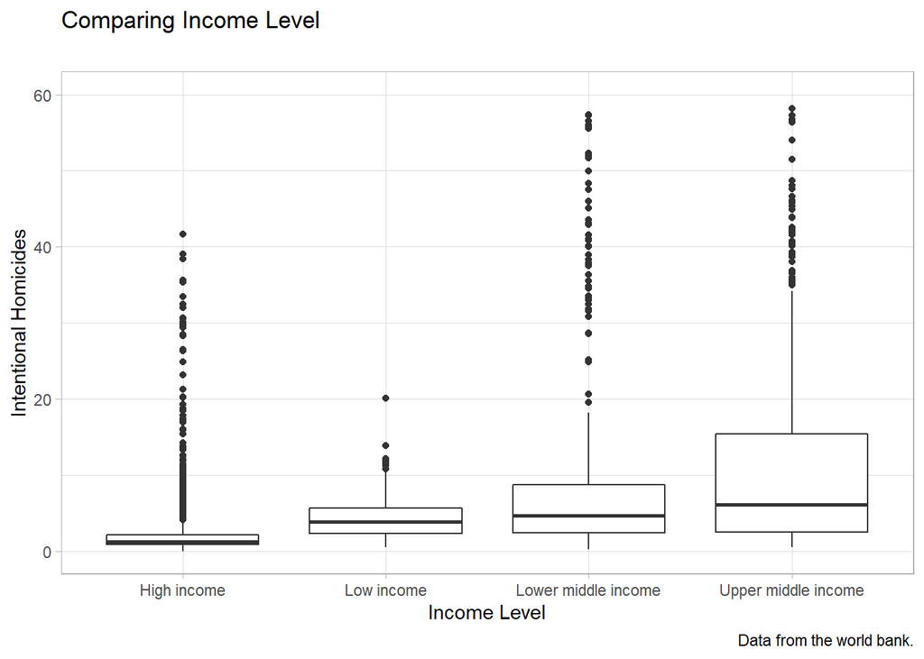

## 5. Statistical Modelling

Train three models with different variables.

```r
# train model 1
fit1 <- lm(formula = SuicideMort ~ IntHomicides + GDPcap,
           data = shg_exp)
# show results
summary(fit1)
```

```
##
## Call:
## lm(formula = SuicideMort ~ IntHomicides + GDPcap, data = shg_exp)
##
## Residuals:
##     Min      1Q  Median      3Q     Max
## -11.789  -6.471  -2.556   3.004  80.575
##
## Coefficients:
##               Estimate Std. Error t value Pr(>|t|)
## (Intercept)  1.130e+01  3.395e-01  33.270   <2e-16 ***
## IntHomicides 1.122e-02  1.787e-02   0.628    0.530
## GDPcap       1.272e-05  1.050e-05   1.212    0.226
## ---
## Signif. codes:  0 '***' 0.001 '**' 0.01 '*' 0.05 '.' 0.1 ' ' 1
##
## Residual standard error: 9.584 on 2305 degrees of freedom
##   (29 Beobachtungen als fehlend gelöscht)
## Multiple R-squared:  0.0006787,  Adjusted R-squared:  -0.0001884
## F-statistic: 0.7827 on 2 and 2305 DF,  p-value: 0.4573
```

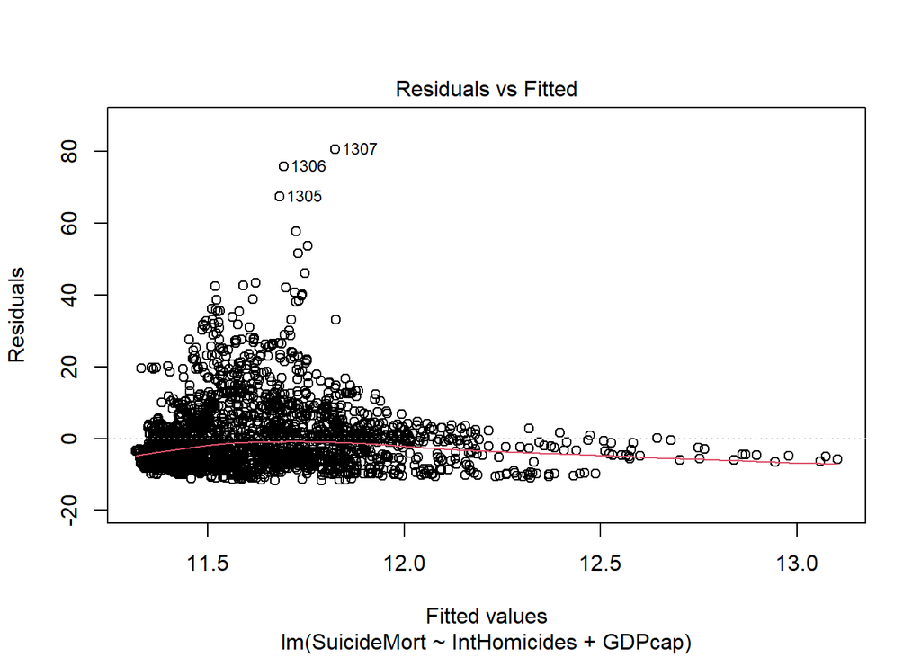

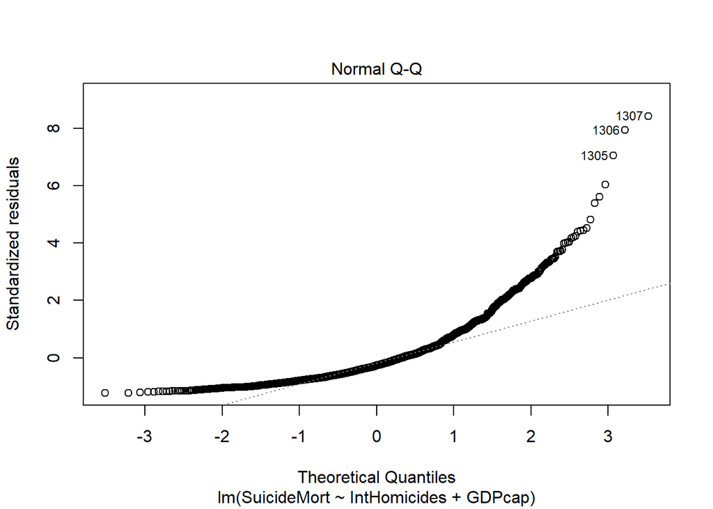

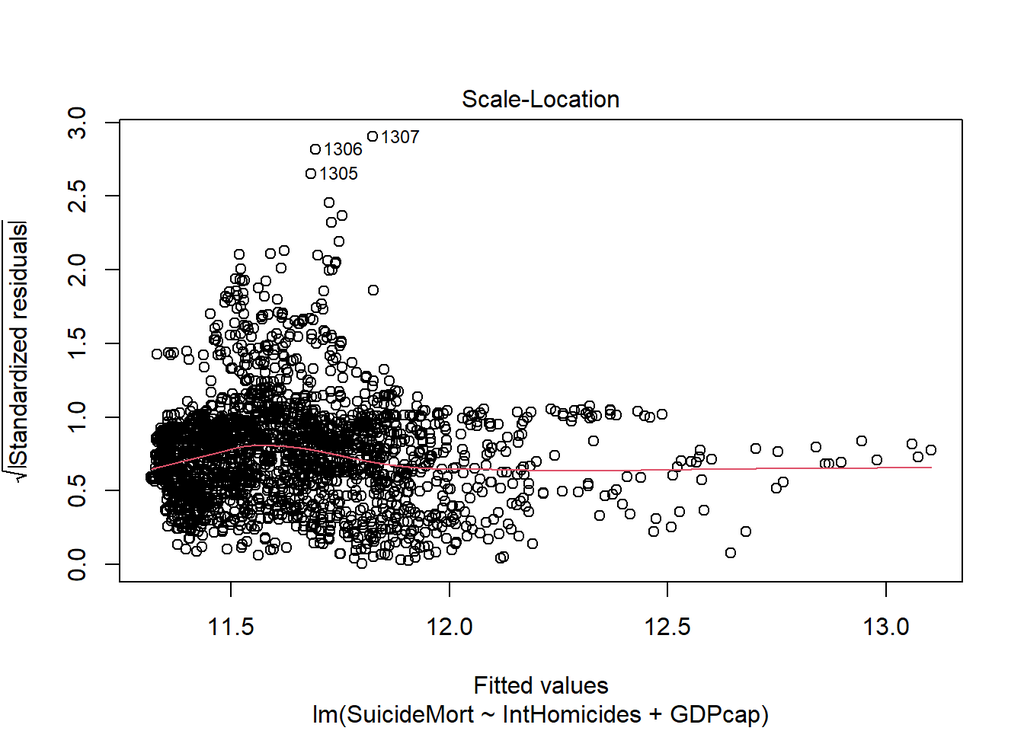

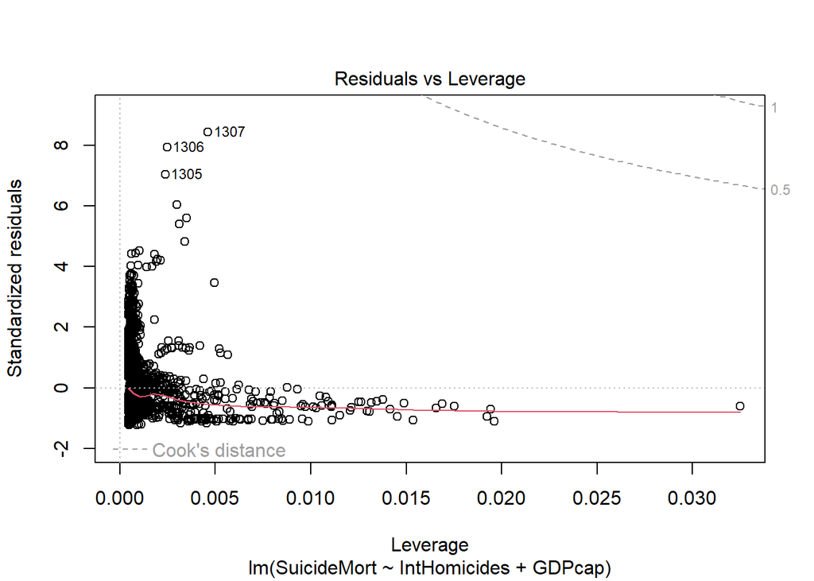

```r
# view diagnostic plot
plot(fit1)
```

```r
# train model 2
fit2 <- lm(formula = SuicideMort ~ incomeLevel,
           data = shg_exp)

# show results
summary(fit2)
```

```
##
## Call:
## lm(formula = SuicideMort ~ incomeLevel, data = shg_exp)
##
## Residuals:
##     Min      1Q  Median      3Q     Max
## -13.160  -6.206  -1.860   2.640  81.922
##
## Coefficients:
##                                Estimate Std. Error t value Pr(>|t|)
## (Intercept)                     13.1598     0.3147  41.821  < 2e-16 ***
## incomeLevelLow income           -6.3931     0.8786  -7.277 4.65e-13 ***
## incomeLevelLower middle income  -2.6815     0.5076  -5.283 1.39e-07 ***
## incomeLevelUpper middle income  -1.7541     0.4666  -3.759 0.000175 ***
## ---
## Signif. codes:  0 '***' 0.001 '**' 0.01 '*' 0.05 '.' 0.1 ' ' 1
##
## Residual standard error: 9.424 on 2333 degrees of freedom
## Multiple R-squared:  0.02814,    Adjusted R-squared:  0.02689
## F-statistic: 22.51 on 3 and 2333 DF,  p-value: 2.285e-14
```

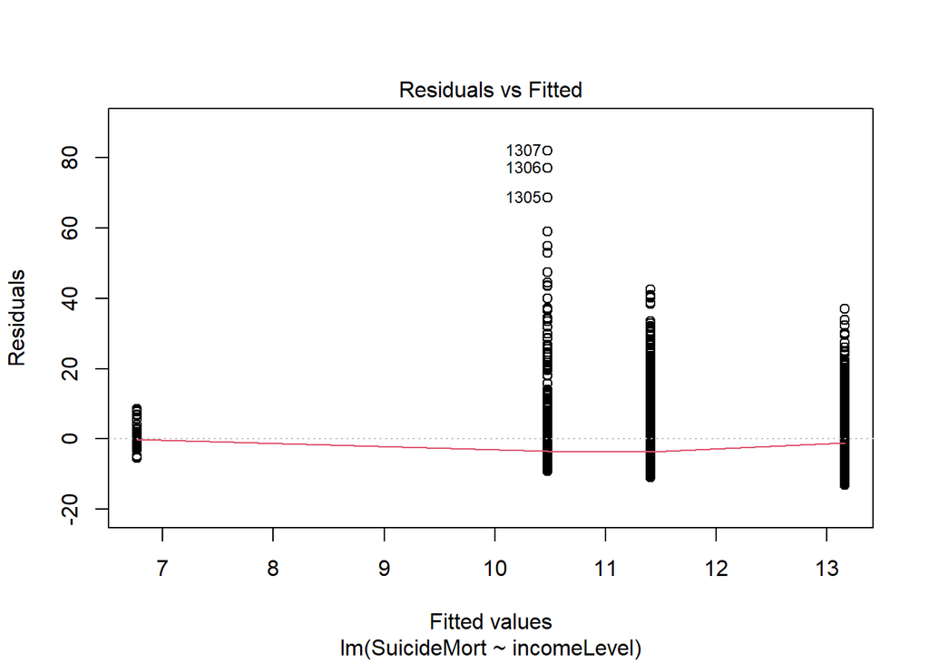

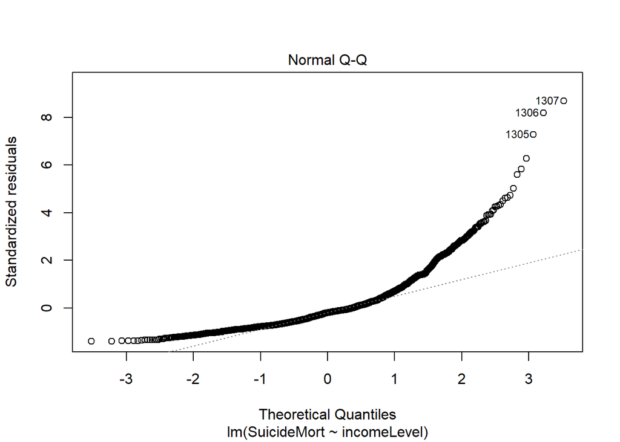

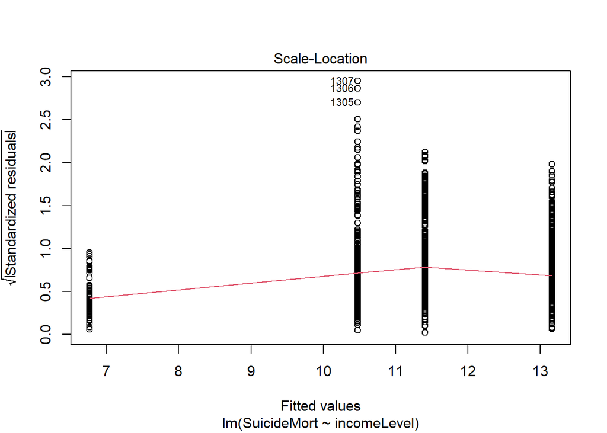

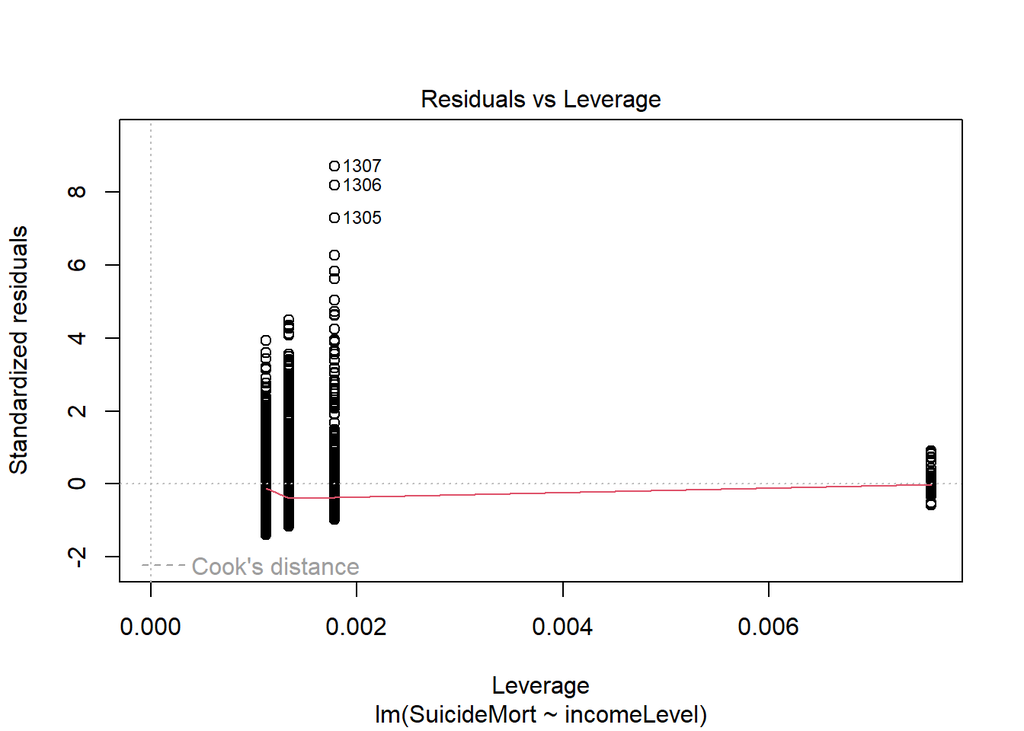

```r
# view diagnostic plot
plot(fit2)
```

```r
# train model 3
fit3 <- lm(formula = SuicideMort ~ regionISO + GDPcap,
           data = shg_exp)

# show results
summary(fit3)
```

```
##
## Call:
## lm(formula = SuicideMort ~ regionISO + GDPcap, data = shg_exp)
##
## Residuals:
##     Min      1Q  Median      3Q     Max
## -16.336  -5.121  -2.336   2.187  79.576
##
## Coefficients:
##                     Estimate Std. Error t value Pr(>|t|)
## (Intercept)        1.292e+01  4.893e-01  26.414  < 2e-16 ***
## regionISOAmericas -4.469e+00  6.255e-01  -7.144 1.21e-12 ***
## regionISOAsia     -3.705e+00  6.198e-01  -5.979 2.60e-09 ***
## regionISOEurope    4.558e+00  6.310e-01   7.224 6.85e-13 ***
## regionISOOceania  -1.258e+00  1.072e+00  -1.174  0.24069
## GDPcap            -3.289e-05  1.015e-05  -3.240  0.00121 **
## ---
## Signif. codes:  0 '***' 0.001 '**' 0.01 '*' 0.05 '.' 0.1 ' ' 1
##
## Residual standard error: 8.841 on 2302 degrees of freedom
##   (29 Beobachtungen als fehlend gelöscht)
## Multiple R-squared:  0.1507, Adjusted R-squared:  0.1489
## F-statistic: 81.71 on 5 and 2302 DF,  p-value: < 2.2e-16
```

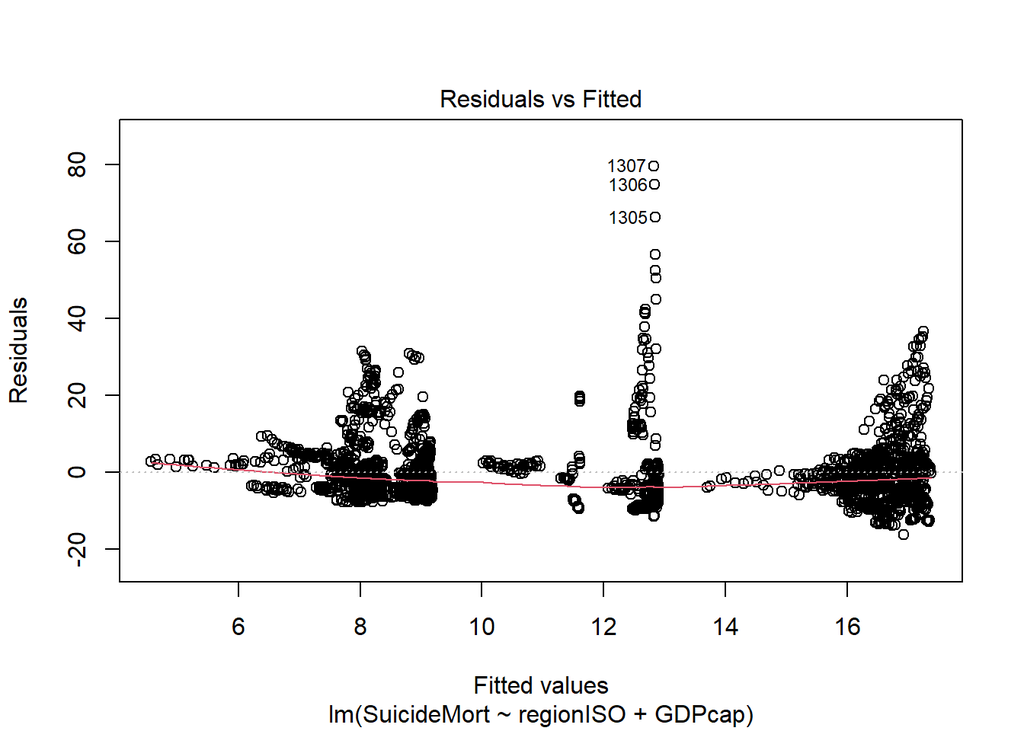

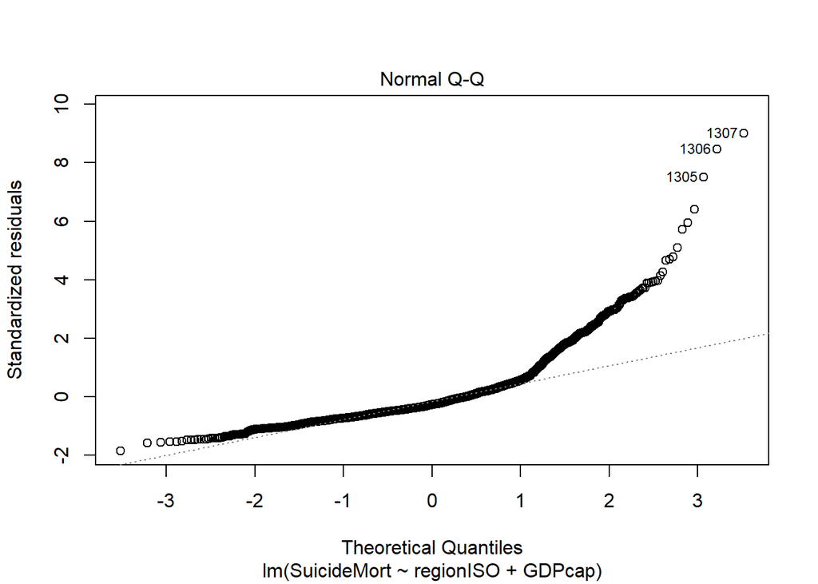

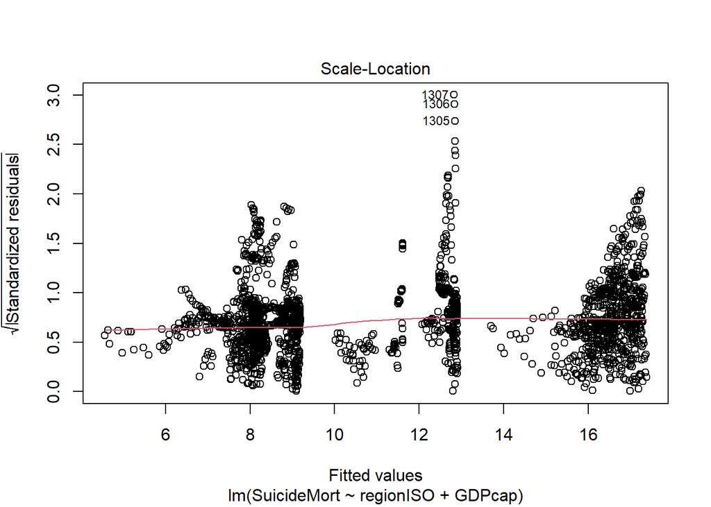

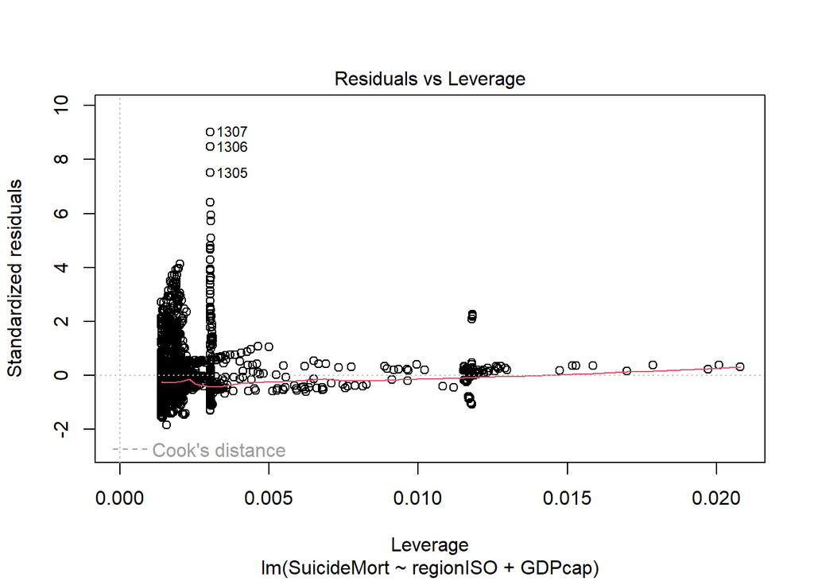

```r
# view diagnostic plot
plot(fit3)
```

### Function for Regression Table in R Markdown

Creating a function to compile the regression table.

```r
# create wrapper around stargazer
starviewer <- function(...) {

  # make sure stargazer is available
  require(stargazer)

  # assume text output but check for latex or html
  star_format <- "text"
  if(knitr::is_latex_output()) {star_format <- "latex"}
  if(knitr::is_html_output())  {star_format <- "html"}

  # if latex, just run stargazer as usual
  if (star_format == "latex") {
    stargazer::stargazer(...)

  } else {

  # if not latex, run stargazer in text / html (or both)
    dir <- tempfile()
    dir.create(dir)
    htmlFile <- file.path(dir, "tempfile.html")
    stargazer::stargazer(..., type = star_format, out = htmlFile)
    rstudioapi::viewer(htmlFile)
  }
}
```

### Regression Table

The p-value should be smaller than 0.05. This is the case for model 2 and model 3. Not for model 1.

A closer look at model 3 (“fit3”): The region has a significant effect on the suicide mortality rate, but not allways in the same directions and not for Ozeania.

```r
starviewer(fit1, fit2, fit3)
```

|  | *Dependent variable:* |  |  |
| --- | --- | --- | --- |
|  | SuicideMort |  |  |
|  | (1) | (2) | (3) |
| IntHomicides | 0.011 |  |  |
|  | (0.018) |  |  |
| regionISOAmericas |  |  | -4.469*** |
|  |  |  | (0.626) |
| regionISOAsia |  |  | -3.705*** |
|  |  |  | (0.620) |
| regionISOEurope |  |  | 4.558*** |
|  |  |  | (0.631) |
| regionISOOceania |  |  | -1.258 |
|  |  |  | (1.072) |
| GDPcap | 0.00001 |  | -0.00003*** |
|  | (0.00001) |  | (0.00001) |
| incomeLevelLow income |  | -6.393*** |  |
|  |  | (0.879) |  |
| incomeLevelLower middle income |  | -2.682*** |  |
|  |  | (0.508) |  |
| incomeLevelUpper middle income |  | -1.754*** |  |
|  |  | (0.467) |  |
| Constant | 11.297*** | 13.160*** | 12.925*** |
|  | (0.340) | (0.315) | (0.489) |
| Observations | 2,308 | 2,337 | 2,308 |
| R<sup>2</sup> | 0.001 | 0.028 | 0.151 |
| Adjusted R<sup>2</sup> | -0.0002 | 0.027 | 0.149 |
| Residual Std. Error | 9.584 (df = 2305) | 9.424 (df = 2333) | 8.841 (df = 2302) |
| F Statistic | 0.783 (df = 2; 2305) | 22.514*** (df = 3; 2333) | 81.709*** (df = 5; 2302) |
| *Note:* | p<0.1; p<0.05; p<0.01 |  |  |